# (In)sensitivity to surface-level heuristics: A case from Turkish verbal attractors

Author

Affiliation

Utku Turk

University of Maryland, College Park

Published

November 10, 2025

Abstract

Linguistic illusion literature has stimulated ongoing debate on what type of information can be used to access memory representations. Prior work tests whether structural, semantic, or discourse cues guide subject-verb dependencies; it remains unclear whether native speakers rely on phonological information as a retrieval cues for memory access during dependency resolution, such as person agreement. Traditionally, accidental phonological resemblance to having a plural ending as in /s/ sound in *course* was found to not induce erroneous plural agreement, meanwhile, phonological resemblance that correlates with controllerhood amplifies attraction given an already present plural morpheme. In apparent contradiction to this generalization, Slioussar (2018) proposed that memory search for a subject in Russian sentences can be mediated through an accidental phonological resemblance. Given the theoretical importance of this proposal and the lack of comparable effects in other languages, we test whether phonological overlap can elicit erroneous agreement in Turkish, where the plural morpheme -lAr surfaces on both nouns and verbs. Turkish provides a critical test: both verbal elements and nominal elements can surface as subjects, but only nominal plural -lAr controls verbal agreement. Two speeded acceptability studies show no attraction from plural-marked verbs (Exp. 1 N = 80; Exp. 2 N = 95) but robust attraction from genitive plural nouns. We report a first-of-its-kind dissociation under minimal manipulation: verbal attractors that can be subjects yet cannot control agreement do not induce attraction, whereas genitive plural nouns that can be subjects and control in other environments do. To our knowledge this pattern has not been shown in any other language, and it constrains cue-based retrieval by tying attraction to abstract controller features rather than surface phonology.

Keywords

form-sensitivity, memory, agreement attraction, linguistic illusions, sentence processing

# Introduction

Human sentence processing draws on abstract grammatical features and on heuristics that exploit surface regularities, such as plausibility (Speer and Clifton 1998), frequency (Lau, Rozanova, and Phillips 2007), and task-specific factors (Laurinavichyute and von der Malsburg 2024; Arehalli and Wittenberg 2021; Hammerly, Staub, and Dillon 2019; Logačev and Vasishth 2016). We focus on one such heuristic, surface-form overlap, where phonological similarity between the sentence constituents modulates performance (Acheson and MacDonald 2011; Kush, Johns, and Van Dyke 2015; Copeland and Radvansky 2001; Rastle and Davis 2008). Prior work shows reliable slowdowns and comprehension accuracy costs under surface-form overlap, but it is unresolved whether this heuristic penetrates dependency resolution itself, including subject-verb agreement, pronoun resolution, or the licensing of negative polarity items, beyond general effects on reading ease and memory. The few studies that bear directly on subject-verb agreement exhibit contradictory findings (Bock and Eberhard 1993; Slioussar 2018).

A central question for understanding human cognition is what information is encoded and later available to memory during comprehension, and how faithful these encodings are to the input. A general cue-based retrieval approaches hold that constituents are stored with detailed abstract features and later accessed by matching retrieval cues; it remains open whether phonological codes persist to serve as such cues during dependency building (Lewis and Vasishth 2005). On the other hand, Good-Enough and noisy accounts allow that detailed analyses are not always maintained when heuristics suffice, raising the possibility that surface regularities affect judgments (Ferreira, Bailey, and Ferraro 2002). Clarifying whether surface-form overlap modulates dependency resolution therefore identifies what human cognition counts as diagnostic information for retrieving dependency controllers and how faithful the stored representations are.

Despite much research on what quantitatively modulates agreement errors, the role of phonology remains unclear. Pseudoplurals attractors such as *course* do not increase agreement errors in production, arguing against a purely phonological route (Bock and Eberhard 1993). Overlaps that align with abstract features or subject-likeness do increase errors, as in case syncretism in German production (Hartsuiker et al. 2003), genitive subject-likeness in Turkish comprehension (Lago et al. 2019), and structural resemblance in Romanian comprehension (Bleotu and Dillon 2024). These effects arise when the attractor bears the relevant plural marking and shares morphological features with a possible subject, not when they are singular but phonologically similar to a plural subject, supporting accounts that downplay surface-form similarity. By contrast, Russian results have been interpreted as evidence that phonological overlap between a singular genitive attractor and a plural nominative form affects agreement judgments, reading, and production (Slioussar 2018).

An alternative interpretation notes that genitive-marked nouns in Russian can participate in other agreement relations, making them plausible agreement controllers in some configurations. This raises the possibility that the observed effects reflect a version of subject-likeness rather than phonology per se. Together, these considerations motivate a targeted test that dissociates the possibility of controllerhood from surface-form overlap.

To this end, we utilize the surface-form overlap between the verbal and nominal morphological reflexes of agreement in Turkish, a language that shows attraction when attractors carry controller-relevant features (Türk and Logačev 2024; Ulusoy 2023; Türk 2022; Lago et al. 2019). Unlike previously tested languages, Turkish uses the same surface suffix, -lAr, for plural marking on nouns and for plural agreement on finite verbs. Typologically, Turkish is agglutinative with a near one-to-one mapping between grammatical meanings and affixes, in contrast to English, a more analytic language where pure phonological overlap has not yielded attraction, and to Russian, a fusional language where overlap effects have been reported. Crucially, strings bearing verbal -lAr can occur in subject position, yet they never control finite clause agreement; only nominal plurals do. These properties allow a direct test of whether form overlap alone modulates agreement errors, or whether modulation requires an element that can in principle serve as an agreement controller.

We report two high-powered speeded acceptability experiments in Turkish. Experiment 1 manipulates the number on an embedded verb that appears near the matrix clause, comparing embedded plural -lAr to embedded singular. Experiment 2 retains this manipulation and adds items with nominal plural attractors drawn from prior Turkish work, creating a within-session benchmark for canonical attraction. Across both experiments, embedded verbal -lAr did not increase acceptance of plural matrix agreement. Nominal plural attractors produced the expected attraction. These results indicate that surface-form overlap alone does not function as a retrieval cue for agreement in Turkish. Dependency resolution appears to rely on abstract features and structural relations, with phonology influencing processing primarily outside of retrieval.

## Background

Studies mainly investigated the interaction between the agremenet process and various syntactic and semantic factors. These factors include hierarchical distance (Hartsuiker, Antón-Méndez, and Van Zee 2001; Nicol, Forster, and Veres 1997; Kaan 2002), linear distance (Neal J. Pearlmutter 2000; Bock and Cutting 1992), semantic interactions of nouns involved (Kathleen M. Eberhard 1999; Vigliocco, Butterworth, and Semenza 1995; Humphreys and Bock 2005), and syntactic category of the phrase containing the attractor (Bock and Miller 1991; Bock and Cutting 1992). A widely accepted accounts of such effects was able to capture these effects by blaming different part of the comprehension and production process. For example, cue-based accounts such as Lewis and Vasishth (2005) or Wagers, Lau, and Phillips (2009) argued that participants have a faithful representation of the constituents they process, however, illusion arises occasionally when they are misled by the memory mechanisms they use to identify the controller. Other accounts such as Marking and Morphing (Kathleen M. Eberhard, Cutting, and Bock 2005), Good-Enough processing (Ferreira, Bailey, and Ferraro 2002), or Rational Inference account (Ryskin, Bergen, and Gibson 2021) argued that the errors mainly arise due to speakers’ representation after encountering linguistic constituents are ill-formed.

However, results from other studies with overt case marking in other languages presents an unclear picture. For instance, Franck et al. (2010) used French and compared the unambiguously accusative marked attractors to NPs with no overt case marking. They showed that when unambiguous marking increased the attraction effects substantially, contrary to the predictions of cue based retrieval. Similarly, Avetisyan, Lago, and Vasishth (2020) also demonstrated that unambiguous case marking in Armenian did not affect neither reading times nor attraction errors.

Slioussar (2018) took these results to be an evidence for a cue-based retrieval model in which attraction effects originates from erroneous retrievals of an agreement controller. Under this approach, phrases are encoded in a content-addressable memory as bundles of features called *chunks* which include information like, number, gender, morphophonological case, and syntactic information (Smith and Vasishth 2020; Lewis and Vasishth 2005). Participants predict the number of the verb based on the noun phrases they process while reading the previous noun phrases. In grammatical sentences with singular verb agreement, the number prediction and the verb number match, which causes no processing difficulty. In contrast, when participants fail to find the predicted number morphology on the verb, a memory-retrieval process is initiated. This process activates the search for a chunk matching relevant cues for agreement controller. Slioussar (2018) argued that the search for a controller can be mediated through possible forms of nouns with relevant features like, case, number, as well as structural cues.

An alternative account that does not depend on activation of relevant features by phonology would depend on encoding of distributional facts as statistical heuristics. In such an account, instead of relying on activation of features through a phonological route, participants would probabilistically associate certain strings, such as genitive marked NP or overt D head, with being an agreement controller. Indeed, similar explanations for syncretism or subject-likeness phenomenon has been reported. For example, Lago et al. (2019) argued that participants can retrieve a noun as the controller if the noun is marked with a case marking that may sometimes control agreement in a language even if that is not the case for the specific sentence. They used Turkish genitive case, which can control the agreement in embedded sentences but not in matrix sentences. They took the presence of attraction effects in Turkish as an indication that Turkish speakers utilize overt genitive-case’s association with subjecthood. In a sense, phonological, not functional, syncretism between the marking on the nominal modifier and the embedded subject resulted in attraction. A similar account from Dillon and colleagues was pushed for sensitivity for looking like a controller in languages like Romanian and Hindi (Bhatia and Dillon 2022; Bleotu and Dillon 2024). For instance, Bleotu and Dillon (2024) manipulated whether the attractor surfaces with a determiner or in its bare form. Importantly, they note that only nouns with determiners can control agreement in Romanian. They found that Romanian attractors only induced attraction effects when both attractor and the head surfaced with a determiner. They took these results to suggest that participants associated presence of a determiner or related feature with the agreement controller, and attraction only surfaces when subject heads and the attractor look alike. Similarly, Schlueter, Williams, and Lau (2018) argue that and can cause agreement attraction effects in English even when it does not create a plurality because it is associated with the plural feature statistically. Such explanations are based on the assumption that the match between a cue and a chunk does not have to be categorical, but it can be influenced by surface level statistical association (Engelmann, Jӓger, and Vasishth 2019).

In Experiment 1, we tested the form hypothesis directly by comparing ungrammatical sentences with verbal-plural vs. verbal-singular attractors. Experiment 2 replicated this design but included additional nominal-attractor items from a previous Turkish attraction study (Türk and Logačev 2024), allowing us to test whether the distribution of item types and the presence of genuine attraction-inducing elements modulates the outcome. Across both experiments, we found no evidence that verbal –lAr induces attraction, even when canonical nominal attractors are present in the same session. This pattern aligns with prior findings in general attraction literature and Turkish agreement attraction, namely surface-form overlap alone does not derive agreement illusions. Rather, attraction appears to depend on abstract feature overlap between potential controllers and agreement probes, and possibly statistical associations between the strings and their controllers. In this lights, findings of Slioussar (2018) are best analyzed as a possible increased association between genitive marking and possible subjecthood and being an agreement controller. By doing so, we hope to clarify how cue-mechanisms are employed and the role of phonological overlap in sentence processing.

# Experiment 1: Testing Form-Driven Processing

## Participants

We recruited 80 undergraduate students to participate in the experiment in exchange for course credit. All participants were native Turkish speakers, with an average age of 21 (range: 18 – 31). The experiment was carried out following the principles of the Declaration of Helsinki and the regulations concerning research ethics at Bogazici University. All participants provided informed consent before their participation and their identities were completely anonymised.

## Materials

All sentences were adapted by previous studies in Turkish agreement attraction (Lago et al. 2019; Türk and Logačev 2024). Sentences started with a complex subject NP like ‘tuttukları aşçı’ ‘the cook they hired,’ in which the nominalized relative clause functioned as the attractor, and the head noun were bare. Because the plural marking on nominals is not optional and the head noun was singular, absent of -lar, in all conditions, sentences with plural verb agreement were ungrammatical. To inhibit participants from forming a task-related strategy in which they deemed the sentence ungrammatical upon seeing a plural verb, half of our fillers included plural grammatical verbs, while the other half included singular ungrammatical verbs.

## Procedures

The experiment was run online, using the web-based platform Ibex Farm (Drummond 2013). Each experimental session took approximately 25 minutes to complete. Participants provided demographic information and gave informed consent to participate in the experiment. They then proceeded to read the instructions and were given nine practice trials before the experiment began.

Each trial began with a blank screen for 600 ms, followed by a word-by-word RSVP presentation of the sentence in the center of the screen, followed by a prompt to indicate their acceptability judgment. Sentences were presented word-by-word in the center of the screen in 30 pt font size, at a rate of 400 ms per word. Participants saw a blank screen for 100 ms between each word, and to see the next item, they needed to press the space key. Participants were asked to press the key P to indicate that a sentence is acceptable and Q to indicate that the sentence is unacceptable. They were instructed to provide judgments as quickly as possible. During the practice, but not during the experiment, a warning message in red font appeared if they did not respond within 5,000 ms.

Participants saw 40 experimental and 40 filler sentences. Experimental sentences were distributed among four different lists according to a Latin-square design. Every participant saw one version of the experiment with a specific list and one item per condition.

## Analysis and Results

Participants showed high accuracy in both grammatical (M = 0.94, CI = [0.92,0.95]) and ungrammatical filler sentences (M = 0.92, CI = [0.9,0.93]), indicating that they understood the task and performed it reliably.

Figure 1 presents the overall means and credible intervals for ‘yes’ responses across experimental conditions. As shown, ungrammatical sentences with plural attractors were rated as acceptable as their counterparts with singular attractors (M = 0.06 and 0.05, CI = [0.04, 0.07] and [0.03, 0.07] for singular and plural attractors, respectively).

On the other hand, accuracy in grammatical conditions was modulated by the number of the attractor in an unexpected way. Participants rated grammatical sentences with singular attractors as grammatical less often (M = 0.92, CI = [0.9,0.94]) compared to their counterpars with plural attractors (M = 0.95, CI = [0.93,0.96]).

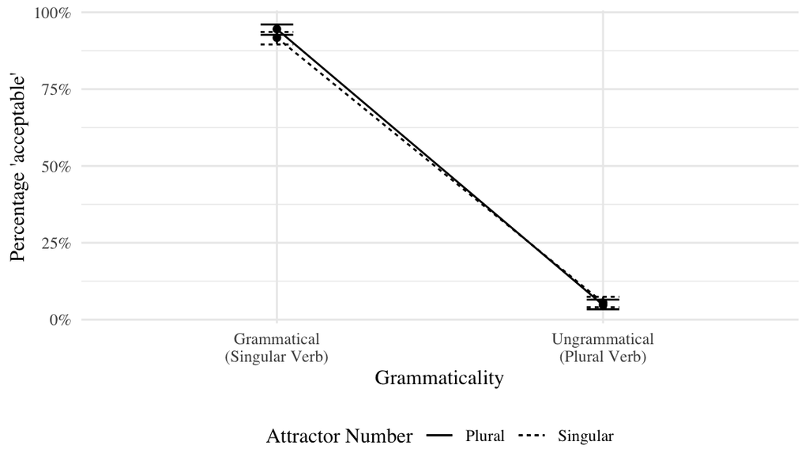

Mean proportion of ‘acceptable’ responses by grammaticality and attractor number. Error bars show 95% Clopper–Pearson confidence intervals.

These descriptive trends were confirmed by our Bayesian mixed-effects models implemented in brms, assuming a Bernoulli logit link. The model was fitted to the binary *yes/no* responses and included fixed effects for Grammaticality and Attractor Number and their interaction, and random intercepts and slopes for both subjects and items.

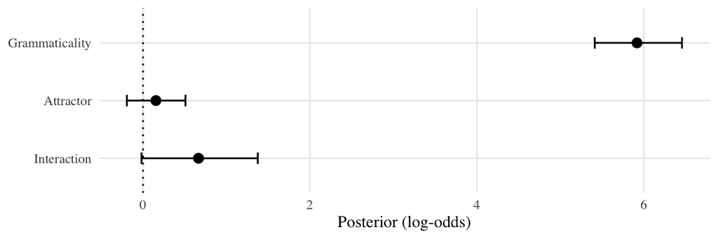

## Discussion

Experiment 1 tested whether phonological overlap between nominal and verbal plural morphemes in Turkish induces agreement attraction. The results provided no evidence for attraction driven by surface-form similarity. Ungrammatical sentences with plural-marked verbs were not judged more acceptable when the relative clause verb contained a plural morpheme. Instead, participants reliably rejected such sentences regardless of attractor number. This indicates that the verbal plural marker -lAr does not create the same type of interference observed with nominal plural attractors in previous studies.

Unexpectedly, grammatical sentences with singular attractors were judged less acceptable than those with plural attractors. This effect is unlikely to reflect agreement attraction, since it arises in the opposite direction. One possibility is that it results from an interaction between plausibility and referential availability. The plural morpheme can license a more general interpretation by allowing an arbitrary or unspecific reference, whereas the singular reduced relative clause more strongly invites a specific referent, which may be less accessible in the context of the task. In other words, plural morphology may facilitate an *arbitrary PRO* interpretation of the embedded clause, in which the understood subject of the relative clause is not controlled by any overt antecedent and has a generic or impersonal reference. A similar effect can be seen in English sentences like ‘Just to sit there should be forbidden.’ Here, the subject of the infinitival clause has arbitrary reference. We do not pursue this explanation further, as it falls outside the scope of the present paper.

One possible reason for the absence of attraction may lie in the within-experiment statistics. Previous work has shown that participants’ global expectations about the frequency of grammatical and ungrammatical sentences can alter attraction patterns. Hammerly, Staub, and Dillon (2019) and Türk (2022) demonstrated that reducing the proportion of grammatical trials led to attraction effects even in otherwise grammatical sentences. Similarly, Arehalli and Wittenberg (2021) reported that filler distribution affects error correction rates. It is possible that the current experiment’s distribution discouraged attraction: if participants rarely encountered conditions that supported attraction, they may have maintained a strong bias against plural-marked verbs, reinforcing this bias throughout the session.

To test this possibility, Experiment 2 introduced additional conditions that have previously been shown to elicit attraction in Turkish . This allowed us to assess whether the inclusion of genuine nominal attractors modulates the likelihood of errors and whether participants adapt to the statistical environment of the task.

# Experiment 2: Testing Within-Experiment Statistical Sensitivity

## Participants

We recruited 95 undergraduate students to participate in the experiment in exchange for course credit. All participants were native Turkish speakers, with an average age of 21 (range: 18 – 30). The experiment was carried out following the principles of the Declaration of Helsinki and the regulations concerning research ethics at Bogazici University. All participants provided informed consent before their participation and their identities were completely anonymised.

## Materials

The same materials were used with Exp1. We added items from Türk and Logačev (2024) as an additional condition for nominal cases.

## Procedures

The same procedure with Experiment 1 was used.

## Analysis and Results

Participants showed high accuracy in both grammatical (M = 0.95, CI = [0.94,0.96]) and ungrammatical filler sentences (M = 0.94, CI = [0.93,0.95]), indicating that they understood the task and performed it reliably.

[figure not shown]

Mean proportion of ‘acceptable’ responses by grammaticality, attractor number and attractor type. Error bars show 95% Clopper–Pearson confidence intervals.

Our models also showed similar results, assuming a Bernoulli logit link. Our main research question was whether verbal attractors induced attraction effects. We also wanted to check whether within-experiment statistics affected the attraction magnitudes, i.e. the effect of presence of verbal attractors on nominal attractors. To that end, we included genitive marked nominals from data from our experiment and Türk and Logačev (2024). The model was fitted to the binary *yes/no* responses and included fixed effects for Grammaticality, Attractor Number, and Attractor Type and their interaction, along with random intercepts and slopes for both subjects and items.

We present posterior summaries of estimated regression effects from our model in Figure 4. We found a robust attraction in both nominal attractor cases, with strongly negative effects for our nominal items (M = -1.45, CI = [-2.12, -0.78], P(<0) = >0.99) and items from Türk and Logačev (2024) (M = -1.16, CI = [-1.63, -0.68], P(<0) = >0.99). More importantly, our model found no evidence for an attraction in verbal attractor conditions (M = 0.08, CI = [-0.7, 0.86], P(<0) = 0.44), verifying our observations in the descriptive statistics. The evidence for a difference in magnitude of attraction between the two genitive types was not found (M = -0.29, CI = [-1.08, 0.51], P(<0) = 0.72), suggesting the within-experimental distribution did not affect attraction magnitudes. Finally, we found strong evidence for a decreased overall acceptability for nominal items in our experiment (M = -1.1, CI = [-1.79, -0.44], P(<0) = >0.99), suggesting the within-experimental distribution did affect overall acceptability, but not attraction.

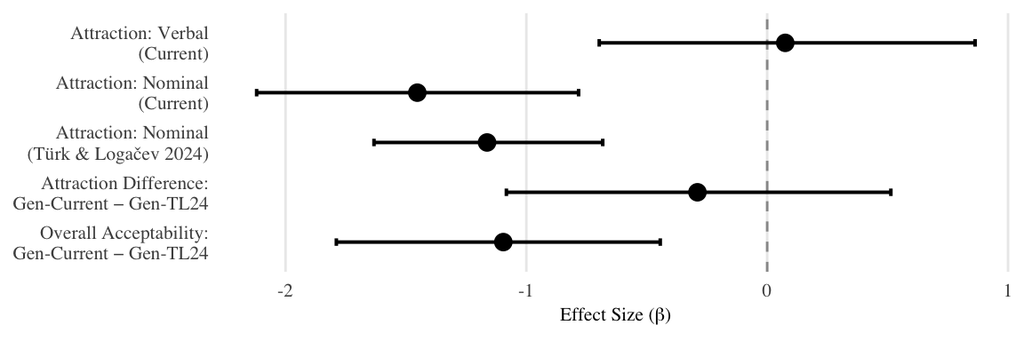

Posterior summaries of attraction-related effects. Points indicate posterior means, and horizontal bars show 95% credible intervals on the log-odds (β) scale. Attraction was estimated as the interaction between grammaticality and attractor number within each attractor type. Negative values indicate stronger attraction (a reduced ungrammaticality penalty in plural-attractor conditions). Dashed line denotes zero (no effect).

## Discussion

Experiment 2 tested whether the reason we did not find attraction effects in Experiment 1 was due to the lack of attraction-inducing conditions. Our results showed that attraction effects in verbal attractor condition, purely phonological overlap, did not surface even when there are robust attraction-inducing trials. Participants reliably rejected ungrammatical sentences with verbal attractors regardless of attractor number.

Our results and between experiment comparison showed that within-experiment statistics, i.e. exposure to verbal attraction conditions attraction items, did not substantially reduced the magnitude of the attraction effects. However, the overall acceptability in our nominal attractor elements were reduced compared to the trials from Türk and Logačev (2024). This is inline with previous findings that shows participants’ judgments within the experiment are modulated by the distribution of trials. Interestingly, previous studies achieved this with instructions or filler elements (Hammerly, Staub, and Dillon 2019; Arehalli and Wittenberg 2021). We show that the experimental conditions and the presence of an effect within a subset of conditions also plays a role in modulating overall acceptability.

# General Discussion

In two high-powered speeded acceptability judgment experiments, we tested whether pure phonological overlap between agreement morphemes can elicit agreement attraction. Our goal was to evaluate previous accounts that attribute attraction to accidental or non-accidental syncretism between forms that can serve as agreement controllers. Turkish provides a useful test case because the plural suffix -lAr appears both on verbs and on nouns, but only nominal -lAr can control agreement. If phonological overlap alone can activate controller-relevant cues, then plural-marked verbs embedded in reduced relative clauses should induce attraction effects even though they cannot syntactically control agreement.

Across both experiments, we found that Turkish attraction is determined by being a potential controller rather than merely resembling one. Participants did not produce or endorse attraction errors in sentences containing verbal attractors, and this absence of attraction persisted even when the same participants showed robust attraction with nominal attractors in the same session.

These results indicate that attraction depends on abstract feature overlap with potential controllers, not on surface-form similarity. This pattern converges with prior results in English and Turkish that failed to find attraction for pseudoplural or phonologically plural forms (Bock and Eberhard 1993; Haskell and MacDonald 2003; Nicol, Barss, and Barker 2016), and stands in contrast to findings from Russian (Slioussar 2018).

In Slioussar (2018), genitive-marked singular nouns that were homophonous with nominative plurals elicited greater attraction effects than their genitive-plural counterparts. This is striking because the relevant nouns lacked a plural feature that could percolate or serve as a retrieval cue. The effect was therefore interpreted as evidence that comprehenders can use phonological form to activate abstract agreement features. However, it is important to note that the evidence for phonological attraction in Russian rests on a small empirical base. The production and comprehension experiments in (Slioussar 2018) included only 32 participants each, and the attraction effects were derived from a small number of error trials (13 in production and 18 in comprehension). Given the low number of critical observations, such effects are vulnerable to sampling variability and may not generalize beyond that dataset.

The high-powered Turkish results challenge that interpretation. Despite identical surface overlap between verbal and nominal plural morphology, phonological similarity alone did not yield attraction. This cross-linguistic contrast suggests that form-based activation of agreement features is not a universal property of the parsing system but, at best, depends on language-specific mappings between morphology and syntactic function (Dillon and Keshev 2024).

A more plausible account is that attraction is modulated by the availability of morphosyntactic features that can signal controllerhood. Syncretism contributes to attraction only when one of the syncretic forms can legitimately control agreement or share features with the target. In other words, it is not form overlap per se, but feature ambiguity that matters. This interpretation aligns with cross-linguistic findings showing that attraction is strongest when the attractor bears case or number morphology that is sometimes associated with subjects or agreement controllers (Lago et al. 2019; Bhatia and Dillon 2022; Bleotu and Dillon 2024; Hartsuiker et al. 2003). Earlier formulations of these models left open whether ‘looking like’ a controller or ‘being able to be’ a controller was critical. The present results favor the latter: only morphologically licensed controllers engage in attraction.

# References

Acheson, Daniel J, and Maryellen C MacDonald. 2011. “The Rhymes That the Reader Perused Confused the Meaning: Phonological Effects During on-Line Sentence Comprehension.” *Journal of Memory and Language* 65 (2): 193–207.

Arehalli, Suhas, and Eva Wittenberg. 2021. “Experimental Filler Design Influences Error Correction Rates in a Word Restoration Paradigm.” *Linguistics Vanguard* 7 (1): 20200052. https://doi.org/doi:10.1515/lingvan-2020-0052.

Avetisyan, Serine, Sol Lago, and Shravan Vasishth. 2020. “Does Case Marking Affect Agreement Attraction in Comprehension?” *Journal of Memory and Language* 112: 104087. https://doi.org/10.1016/j.jml.2020.104087.

Bhatia, Sakshi, and Brian Dillon. 2022. “Processing Agreement in Hindi: When Agreement Feeds Attraction.” *Journal of Memory and Language* 125: 104322.

Bleotu, Adina Camelia, and Brian Dillon. 2024. “Romanian (Subject-Like) DPs Attract More Than Bare Nouns: Evidence from Speeded Continuations.” *Journal of Memory and Language* 134: 104445.

Bock, Kathryn, and John Cooper Cutting. 1992. “Regulating Mental Energy: Performance Units in Language Production.” *Journal of Memory and Language* 31 (1): 99–127. https://doi.org/10.1016/0749-596X(92)90007-K.

Bock, Kathryn, and Kathleen M Eberhard. 1993. “Meaning, Sound and Syntax in English Number Agreement.” *Language and Cognitive Processes* 8 (1): 57–99. https://doi.org/10.1080/01690969308406949.

Bock, Kathryn, and Carol A Miller. 1991. “Broken Agreement.” *Cognitive Psychology* 23 (1): 45–93. https://doi.org/10.1016/0010-0285(91)90003-7.

Copeland, David E, and Gabriel A Radvansky. 2001. “Phonological Similarity in Working Memory.” *Memory & Cognition* 29 (5): 774–76. https://doi.org/10.3758/BF03200480.

Dillon, Brian, and Maayan Keshev. 2024. “Syntactic Dependency Formation in Sentence Processing: A Comparative Perspective.” In *The Cambridge Handbook of Comparative Syntax*, edited by Sjef Barbiers, Norbert Corver, and Maria Polinsky, 1031–69. Cambridge: Cambridge University Press.

Drummond, Alex. 2013. “*Ibex Farm*.”

Eberhard, Kathleen M. 1999. “The Accessibility of Conceptual Number to the Processes of Subject–Verb Agreement in English.” *Journal of Memory and Language* 41 (4): 560–78. https://doi.org/10.1006/jmla.1999.2662.

Eberhard, Kathleen M., J. Cooper Cutting, and Kathryn Bock. 2005. “Making Syntax of Sense: Number Agreement in Sentence Production.” *Psychological Review* 112 (3): 531–59. https://doi.org/10.1037/0033-295X.112.3.531.

Engelmann, Felix, Lena A Jӓger, and Shravan Vasishth. 2019. “The Effect of Prominence and Cue Association on Retrieval Processes: A Computational Account.” *Cognitive Science* 43 (12): e12800.

Ferreira, Fernanda, Karl GD Bailey, and Vittoria Ferraro. 2002. “Good-Enough Representations in Language Comprehension.” *Current Directions in Psychological Science* 11 (1): 11–15.

Franck, Julie, Gabriela Soare, Ulrich H Frauenfelder, and Luigi Rizzi. 2010. “Object Interference in Subject–Verb Agreement: The Role of Intermediate Traces of Movement.” *Journal of Memory and Language* 62 (2): 166–82.

Hammerly, Christopher, Adrian Staub, and Brian Dillon. 2019. “The Grammaticality Asymmetry in Agreement Attraction Reflects Response Bias: Experimental and Modeling Evidence.” *Cognitive Psychology* 110: 70–104. https://doi.org/10.1016/j.cogpsych.2019.01.001.

Hartsuiker, Robert J, Inés Antón-Méndez, and Marije Van Zee. 2001. “Object Attraction in Subject-Verb Agreement Construction.” *Journal of Memory and Language* 45 (4): 546–72. https://doi.org/10.1006/jmla.2000.2787.

Hartsuiker, Robert J, Herbert J Schriefers, Kathryn Bock, and Gerdien M Kikstra. 2003. “Morphophonological Influences on the Construction of Subject–Verb Agreement.” *Memory & Cognition* 31 (8): 1316–26. https://doi.org/10.3758/bf03195814.

Haskell, Todd R, and Maryellen C MacDonald. 2003. “Conflicting Cues and Competition in Subject–Verb Agreement.” *Journal of Memory and Language* 48 (4): 760–78. https://doi.org/10.1016/S0749-596X(03)00010-X.

Humphreys, Karin R, and Kathryn Bock. 2005. “Notional Number Agreement in English.” *Psychonomic Bulletin & Review* 12 (4): 689–95. https://doi.org/10.3758/BF03196759.

Kaan, Edith. 2002. “Investigating the Effects of Distance and Number Interference in Processing Subject-Verb Dependencies: An ERP Study.” *Journal of Psycholinguistic Research* 31 (2): 165–93. https://doi.org/10.1023/A:1014978917769.

Kush, Dave, Clinton L Johns, and Julie A Van Dyke. 2015. “Identifying the Role of Phonology in Sentence-Level Reading.” *Journal of Memory and Language* 79: 18–29.

Lago, Sol, Martina Gračanin–Yuksek, Duygu Fatma Şafak, Orhan Demir, Bilal Kırkıcı, and Claudia Felser. 2019. “Straight from the Horse’s Mouth: Agreement Attraction Effects with Turkish Possessors.” Journal Article. *Linguistic Approaches to Bilingualism* 9 (3): 398–426. https://doi.org/10.1075/lab.17019.lag.

Lago, Sol, Diego E. Shalom, Mariano Sigman, Ellen F. Lau, and Colin Phillips. 2015. “Agreement Attraction in Spanish Comprehension.” *Journal of Memory and Language* 82: 133–49. https://doi.org/10.1016/j.jml.2015.02.002.

Lau, Ellen, Katya Rozanova, and Colin Phillips. 2007. “Syntactic Prediction and Lexical Surface Frequency Effects in Sentence Processing.” *University of Maryland Working Papers in Linguistics* 16: 163–200.

Laurinavichyute, Anna, and Titus von der Malsburg. 2024. “Agreement Attraction in Grammatical Sentences and the Role of the Task.” *Journal of Memory and Language* 137: 104525. https://doi.org/https://doi.org/10.1016/j.jml.2024.104525.

Lewis, Richard L., and Shravan Vasishth. 2005. “An Activation-Based Model of Sentence Processing as Skilled Memory Retrieval.” *Cognitive Science* 29 (3): 375–419.

Logačev, Pavel, and Shravan Vasishth. 2016. “A Multiple-Channel Model of Task-Dependent Ambiguity Resolution in Sentence Comprehension.” *Cognitive Science* 40 (2): 266–98.

Nicol, Janet L., Andrew Barss, and Jason E. Barker. 2016. “Minimal Interference from Possessor Phrases in the Production of Subject–Verb Agreement.” *Frontiers in Psychology* 7 (548): 1–12. https://doi.org/10.3389/fpsyg.2016.00548.

Nicol, Janet L., K. I. Forster, and C. Veres. 1997. “Subject-Verb Agreement Processes in Comprehension.” *Journal of Memory and Language* 36 (4): 569–87. https://doi.org/10.1006/jmla.1996.2497.

Pearlmutter, Neal J. 2000. “Linear Versus Hierarchical Agreement Feature Processing in Comprehension.” *Journal of Psycholinguistic Research* 29 (1): 89–98. https://doi.org/10.1023/A:1005128624716.

Pearlmutter, Neal J., Susan M. Garnsey, and Kathryn Bock. 1999. “Agreement Processes in Sentence Comprehension.” *Journal of Memory and Language* 41 (3): 427–56. https://doi.org/10.1006/jmla.1999.2653.

Rastle, Kathleen, and Matthew H Davis. 2008. “Morphological Decomposition Based on the Analysis of Orthography.” *Language and Cognitive Processes* 23 (7-8): 942–71. https://doi.org/10.1080/01690960802069730.

Ryskin, Rachel, Leon Bergen, and Edward Gibson. 2021. “Agreement Errors Are Predicted by Rational Inference in Sentence Processing.”

Schlueter, Zoe, Alexander Williams, and Ellen Lau. 2018. “Exploring the Abstractness of Number Retrieval Cues in the Computation of Subject-Verb Agreement in Comprehension.” *Journal of Memory and Language* 99: 74–89.

Siewierska, Anna. 2013. “Verbal Person Marking (V2020.4).” Data set. In *The World Atlas of Language Structures Online*, edited by Matthew S. Dryer and Martin Haspelmath. Zenodo. https://doi.org/10.5281/zenodo.13950591.

Slioussar, Natalia. 2018. “Forms and Features: The Role of Syncretism in Number Agreement Attraction.” *Journal of Memory and Language* 101: 51–63. https://doi.org/10.1016/j.jml.2018.03.006.

Smith, Garrett, and Shravan Vasishth. 2020. “A Principled Approach to Feature Selection in Models of Sentence Processing.” *Cognitive Science* 44 (12): e12918.

Speer, Shari R, and Charles Clifton. 1998. “Plausibility and Argument Structure in Sentence Comprehension.” *Memory & Cognition* 26 (5): 965–78.

Tucker, Matthew A., Ali Idrissi, and Diogo Almeida. 2015. “Representing Number in the Real-Time Processing of Agreement: Self-Paced Reading Evidence from Arabic.” *Frontiers in Psychology* 6 (347): 1–21. https://doi.org/10.3389/fpsyg.2015.00347.

Türk, Utku. 2022. “Agreement Attraction in Turkish.” PhD thesis, İstanbul, Turkey: Bogaziçi University.

Türk, Utku, and Pavel Logačev. 2024. “Agreement Attraction in Turkish: The Case of Genitive Attractors.” *Language, Cognition and Neuroscience* 39 (4): 448–54.

Ulusoy, Elifnur. 2023. “Connectivity and Case Effects in Agreement Attraction: The Case of Turkish.” University of California, Santa Cruz.

Vigliocco, Gabriella, Brian Butterworth, and Carlo Semenza. 1995. “Constructing Subject-Verb Agreement in Speech: The Role of Semantic and Morphological Factors.” *Journal of Memory and Language* 34 (2): 186–215. https://doi.org/10.1006/jmla.1995.1009.

Wagers, Matthew W., Ellen F. Lau, and Colin Phillips. 2009. “Agreement Attraction in Comprehension: Representations and Processes.” *Journal of Memory and Language* 61 (2): 206–37. https://doi.org/10.1016/j.jml.2009.04.002.